# Mixed-effects models

PCB 6455 / BSC 4933: Biometry | Lecture 25

Dr. Brian Maitner

## Today’s agenda

1. Rows that come in **groups**
2. What a **random effect** is
3. `lmer()`: wing shape within bird families; your turn: two rules of biogeography
4. `glmer()`: bobwhite routes, counted every year; your turn: development
5. Your turn: which songbirds migrate, with families
6. Beyond groups: rows linked by space, time and ancestry
7. Random or fixed? Which tool, when

Type and run on a code block: type it into your script and run it. Code without the label is there to watch.

## The story so far

- Lecture 23: `lm()`, for normal scatter around a linear mean
- Lecture 24: `glm()`, for yes/no data and counts, through a link
- **Today:** what to do when the rows **come in groups** and are not independent

# Rows that come in groups

## The independence assumption

Every likelihood since Lecture 15 **adds up** one log-probability per row. That is only right if the rows are **independent**: knowing one row tells you nothing extra about another. Common ways that breaks:

- **A good spot.** The plants in one plot are all large because the plot sits on good soil. Twenty plants, but one lucky location.
- **An unusual individual.** Thirty of your fifty foraging observations come from one bold animal. Your “species behavior” is mostly its behavior.
- **A few lineages dominate.** Most measured bird growth rates come from pheasants and quail (Phasianidae) and ducks (Anatidae), so the overall trend is mostly theirs.

Rows that share a place, an individual or an ancestry are partly repeats, but our tools count each one as new and let whoever has the most rows steer.

## The same routes, every year

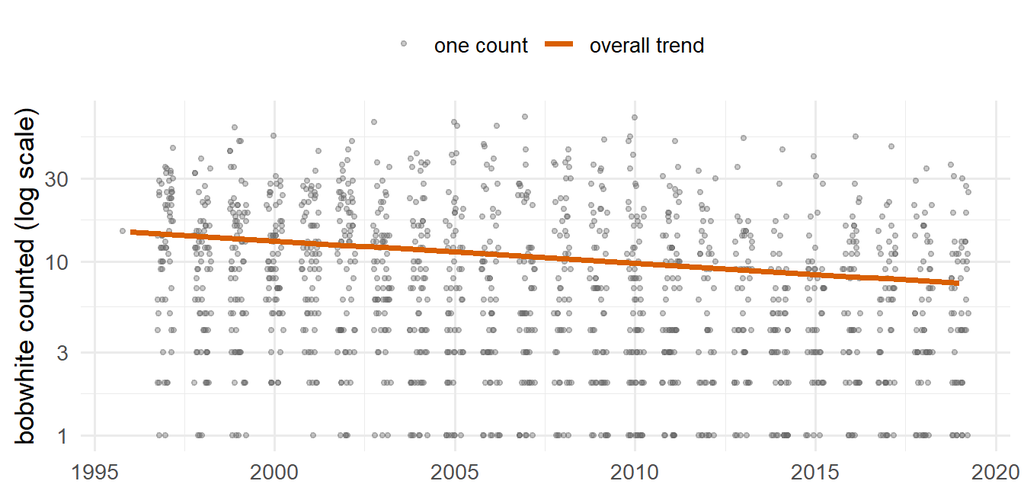

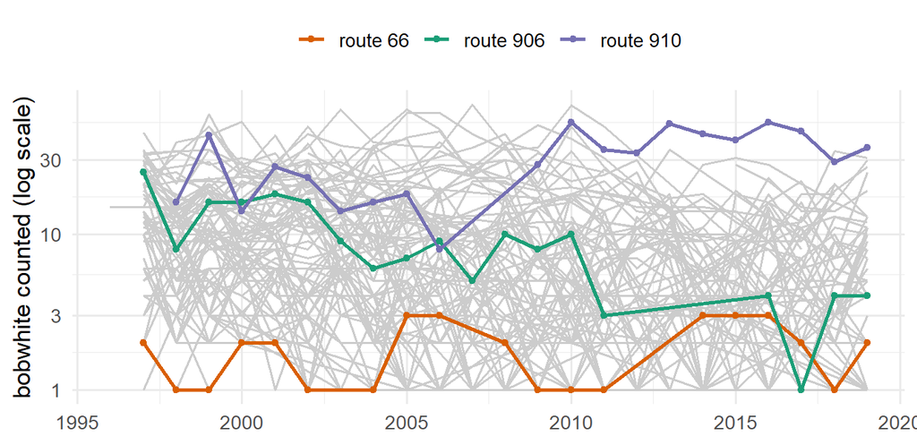

Lecture 15: 1,360 counts, one trend, about 2.9% fewer birds a year.

But they come from just **100 routes**, each counted for up to 23 years. Routes differ in **how many birds** they have, and in **how they change**.

## Groups are everywhere

| The group | Rows within it |
| --- | --- |
| a survey route, a reef, a site | counted every year |
| an animal | weighed, tracked or sampled again and again |
| a plot | quadrats or seedlings within it |
| a family or genus | species that share an ancestor |
| Lecture 22’s ROV dives | 729 video sections from 5 dives |

Does your Assignment 4 dataset have a column like this?

## Three ways to handle a group

|  | Ignore it | A **fixed** effect | A **random** effect |
| --- | --- | --- | --- |
| in R | `count ~ decade` | `count ~ decade + route` | `count ~ decade + (1 \| route)` |
| estimates | nothing about routes | 99 route differences | **one** number: how much routes differ |
| the catch | treats every row as independent | many parameters; nothing to say about a new route | needs enough groups (about 5 or more) |

## What a random effect is

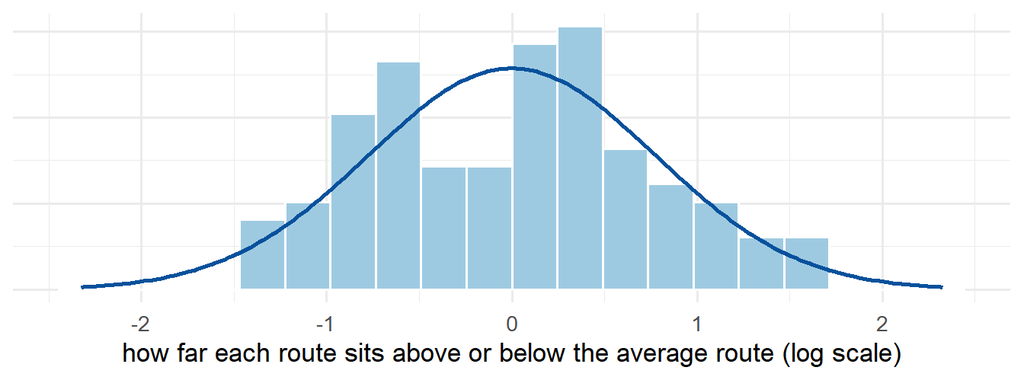

Each route gets its **own intercept**, drawn from a **normal distribution** centered on the average route. The model estimates that distribution’s **standard deviation**: here 0.78 on the log scale, so a route one standard deviation above average has 2.2 times the birds.

A random effect says the groups differ, and estimates how much, instead of estimating every group separately.

# `lmer()`: wings within families

## Wings run in families

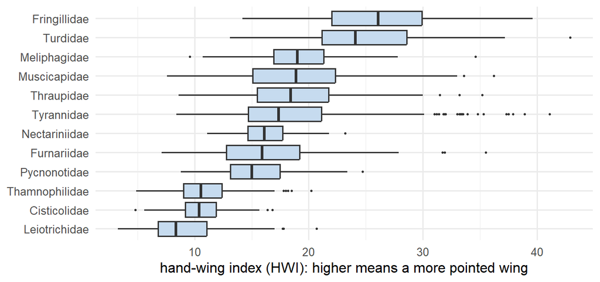

Lecture 23 fit `hwi ~ lat` across 6,583 songbirds as if each species were independent. But **relatives share a wing**: a swallow has pointed wings partly because its ancestors did.

## Get set up

```r
library(lme4)      # mixed models: install it first if you need to
library(bbmle)
library(biometrydata)

songbirds <- avonet[avonet$Order1 == "Passeriformes", ]
birds <- data.frame(species = songbirds$Species1,
                    family = songbirds$Family1,
                    hwi = songbirds$Hand.Wing.Index,
                    lat = abs(songbirds$Centroid.Latitude),
                    migratory = as.numeric(songbirds$Migration == 3))
birds <- na.omit(birds)

nrow(birds)                     # species
length(unique(birds$family))    # families
```

**Check:** 6,583 species in 138 families.

## Fit it

```r
# names: lm_ for lm() fits, mm_ for mixed models
lm_lat <- lm(hwi ~ lat, data = birds)                   # every species independent
mm_lat <- lmer(hwi ~ lat + (1 | family), data = birds)  # each family its own intercept

coef(lm_lat)
summary(mm_lat)
```

`(1 | family)`: “an intercept (`1`) that varies by (`|`) family”.

**Check:** the latitude slope drops from 0.171 to 0.148 HWI units per degree.

## Reading the output

| From `summary(mm_lat)` | Value | What it means |
| --- | --- | --- |
| Random effects: family, Std.Dev. | 6.41 | how much **families** differ in average HWI |
| Random effects: Residual, Std.Dev. | 4.27 | how much **species within a family** differ |
| Fixed effects: lat | 0.148 | HWI units per degree from the equator |

Square the standard deviations to get variances, and ask what share is between families:

$$\frac{41.1}{41.1 + 18.2} = 69%$$

69% of the variation in wing shape is **between families**: two species from the same family are much alike.

## The bar, decoded

| Term | Says |
| --- | --- |
| `(1 \| family)` | each family has its own **intercept** |
| `(1 + lat \| family)` | each family has its own intercept **and its own slope** for latitude |
| `(1 \| site/plot)` | plots **nested** within sites: plot 1 at site A is not plot 1 at site B |
| `(1 \| site) + (1 \| year)` | **crossed**: every site was visited in every year |

## Small families borrow from big ones

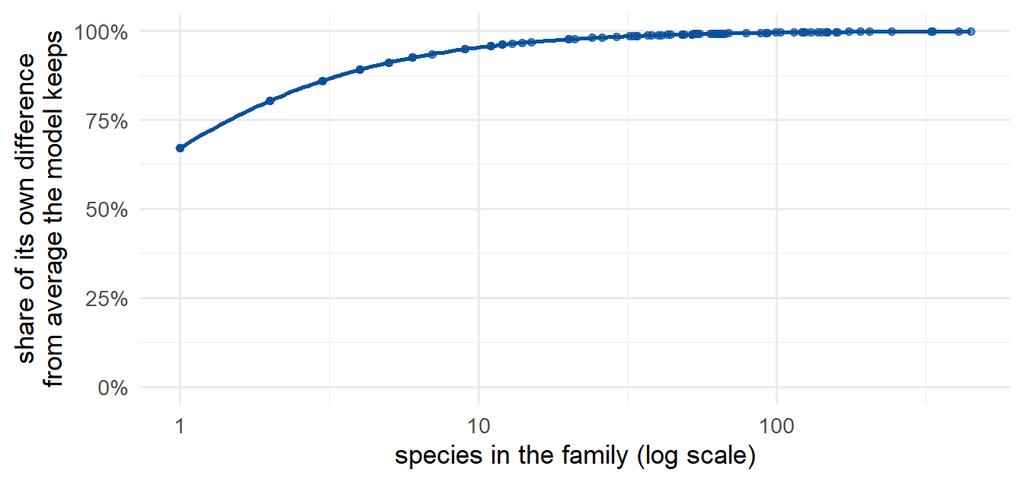

Eupetidae has one species, with an HWI of 4.0, far below the average of 17.5. The model keeps only 67% of that difference and puts the family at 8.4. **Small families are pulled toward the average; big ones keep their own.**

A family with one species is mostly guesswork, so the model trusts it less and leans on what all the other families say.

## Why did the slope change?

|  | `lm(hwi ~ lat)` | `lmer(hwi ~ lat + (1 \| family))` |
| --- | --- | --- |
| slope, HWI per degree | 0.171 | 0.148 |
| standard error | 0.0066 | 0.0045 |

- `lm()` compares **any two species**: part of its slope is “families far from the equator have pointier wings”
- `lmer()` leans on comparisons **within families**: “a species that lives farther from the equator than its relatives has pointier wings than they do”
- Here the interval got **narrower**: family soaks up variation that was noise to `lm()`. Your turn shows it can go the other way.

## Compare, and get intervals

`lmer()` fits by **REML** by default, which gives better standard deviations but cannot compare models with different fixed effects. For **AIC**, refit with `REML = FALSE`.

```r
mm_lat_ml  <- lmer(hwi ~ lat + (1 | family), data = birds, REML = FALSE)
mm_null_ml <- lmer(hwi ~ 1 + (1 | family), data = birds, REML = FALSE)
AICtab(lm_lat, mm_null_ml, mm_lat_ml)

confint(mm_lat_ml)     # profile intervals, as in Lecture 17
```

**Check:** `mm_lat_ml` wins by 1,019 over no latitude and by 6,617 over `lm_lat`. Slope 0.140 to 0.157.

## Your turn: two rules of biogeography

**Bergmann’s rule:** animals are heavier toward the poles. **Rapoport’s rule:** ranges are larger toward the poles. Do songbirds follow them?

```r
rules <- data.frame(family = songbirds$Family1,
                    lat = abs(songbirds$Centroid.Latitude),
                    mass = songbirds$Mass,           # grams
                    range = songbirds$Range.Size)    # square km
rules <- na.omit(rules)

lm_mass <- lm(log(mass) ~ lat, data = rules)
# mm_mass: the same, with a random intercept for family
# lm_range, mm_range: the same two models for log(range)

# share between families: vc <- as.data.frame(VarCorr(mm_mass)); vc$vcov[1] / sum(vc$vcov)
# latitude intervals: confint() on each
```

**Before you fit:** which runs more in families, body mass or range size?

## What the two rules show

|  | body mass | range size |
| --- | --- | --- |
| share between families | **74%** | **15%** |
| latitude slope, `lm()` | -0.0010 (-0.0025 to 0.0005) | 0.0548 |
| latitude slope, `lmer()` | -0.0008 (-0.0018 to 0.0002) | 0.0585 |

- **Range size barely runs in families**, so `lmer()` barely changes its answer: ranges about 1.8 times larger every 10 degrees from the equator
- **Body mass runs strongly in families**, but neither model finds Bergmann’s rule: both intervals include zero. A random effect does not create an effect.

The more a trait runs in groups, the more a mixed model changes the answer; when groups barely differ, it agrees with lm().

# `glmer()`: bobwhite routes

## `glmer()` is `glm()` with groups

Same `family =`, same link, plus a bar term. Back to the routes:

```r
bw <- bobwhite_counts
bw$route <- factor(bw$route)    # route numbers are names, not amounts
bw$decade <- bw$elapsed / 10    # decades since 1996: glmer() prefers numbers near 1

nrow(bw)
length(unique(bw$route))
```

**Check:** 1,360 counts on 100 routes.

## Fit it

```r
# Lecture 15's model: a negative binomial, every count independent
g_nb <- MASS::glm.nb(count ~ decade, data = bw)

# the same decline, with a random intercept for route
mm_pois <- glmer(count ~ decade + (1 | route), family = poisson, data = bw)
mm_nb <- glmer.nb(count ~ decade + (1 | route), data = bw)

AICtab(g_nb, mm_pois, mm_nb)
```

**Check:** `mm_nb` wins, by 1,020 over ignoring routes and by 1,384 over the Poisson.

## Undo the link

```r
b <- fixef(mm_nb)["decade"]    # fixef(): the fixed effects, on the log scale, per decade
exp(b)                         # birds multiplied by this per decade
exp(b / 10)                    # ... and per year

ci <- confint(mm_nb, parm = "beta_", method = "Wald")
exp(ci["decade", ] / 10)       # per year, with a 95% interval

exp(coef(g_nb)["decade"] / 10) # Lecture 15's answer, for comparison
```

**Check:** 0.961 a year: **3.9% fewer birds each year** (3.4% to 4.3%), against 2.9% when routes are ignored.

## Why is the decline steeper?

|  | ignore routes, `glm.nb()` | `glmer(poisson)` | `glmer.nb()` |
| --- | --- | --- | --- |
| decline per year | 2.9% | 3.2% | **3.9%** |
| 95% interval | 2.2% to 3.6% | 3.0% to 3.5% | 3.4% to 4.3% |
| inside the 95% range | 96% | 82% | 97% |

- Routes **leave these data** when no bobwhite are seen: about 66 routes a year in 1997 to 2001, 50 in 2015 to 2019
- The routes left are the **good** ones: 24% above an average route, against 6% early on
- Ignoring routes, good routes in later years **hide** part of the decline. With a random effect, **each route is compared with itself**.

## Your turn: does development explain the routes?

Lecture 16’s `frac_built`: the share of land built up around each route, measured **once per route**.

```r
g_built <- MASS::glm.nb(count ~ decade + frac_built, data = bw)
# mm_built: the same, plus a random intercept for route (hint: glmer.nb())

# frac_built's estimate and standard error in each model:
#   summary(...)$coefficients["frac_built", 1:2]

# how much routes differ, before and after: VarCorr(mm_nb), VarCorr(mm_built)

# for anyone fast: AICtab(mm_nb, mm_built)
```

**Before you fit:** 1,360 counts, but `frac_built` takes one value per route. Will its standard error grow or shrink?

## What development shows

- **Built-up routes have fewer bobwhite:** every 10 percentage points of built land, about 27% fewer birds
- **Its standard error grows 2.6 times.** `glm.nb()` counted 1,360 pieces of evidence about development; there are about 100, one per route
- **It explains part of why routes differ:** the route standard deviation falls from 0.78 to 0.71

A predictor measured once per group gets about one piece of evidence per group, however many rows each group has.

## Does each route decline at its own rate?

```r
mm_slope <- glmer.nb(count ~ decade + (1 + decade | route), data = bw)
```

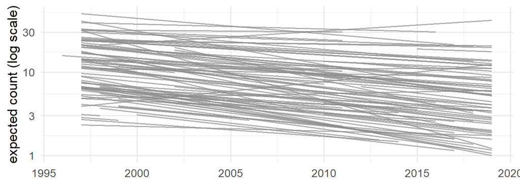

AIC prefers it by 110. The average route loses 4.6% a year, but routes vary: most fall between 11.4% fewer and 2.7% more birds a year.

## The average route is not every route

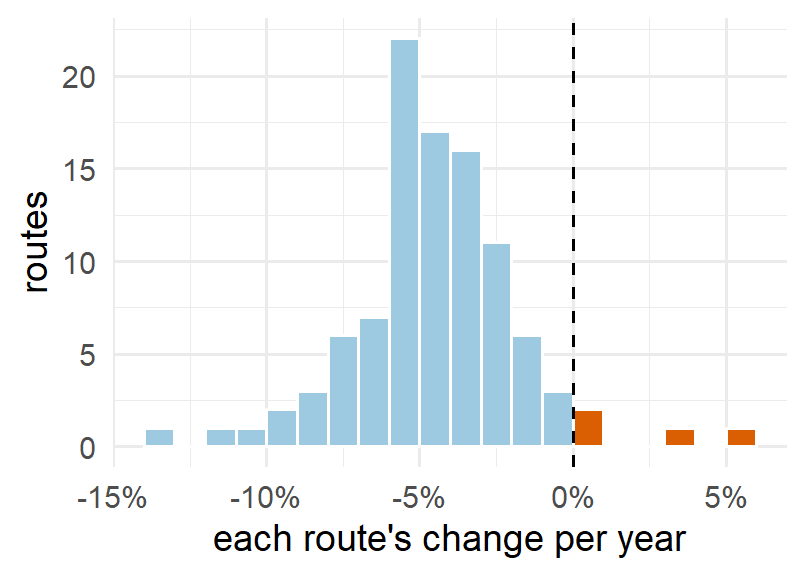

“Bobwhite are declining 4.6% a year” describes the **average** route.

Routes run from about 14% fewer birds a year to 5% more, and the model puts about **1 route in 9** on the rise.

- The **ecological fallacy**: assuming a pattern in the whole holds for each part
- It runs the other way too: **across** routes the decline looked shallower (2.9%) than **within** them (3.9%)

A trend in the average is not a trend in every member: the population can fall while some routes grow.

## When `lmer()` and `glmer()` complain

| Message | Usually means | Try |
| --- | --- | --- |
| “very large eigenvalue: Rescale variables?” | predictors on very different scales | decades not years; `scale(x)` |
| “Model failed to converge” | the optimizer stopped early (Lecture 20) | rescale; fewer random slopes |
| “boundary (singular) fit” | a standard deviation estimated at 0 | too few groups, or that term does not vary: drop it |

# Your turn

## Your turn: migration, with families

```r
# Lecture 24's model: every species independent
g_add <- glm(migratory ~ lat + hwi, family = binomial, data = birds)

# mm_mig: the same model, plus a random intercept for family
# (hint: glmer() takes the same family = as glm())

# odds ratios side by side: exp(coef()) for g_add, exp(fixef()) for mm_mig

# standard errors: the second column of summary(...)$coefficients, for each
```

**Before you fit:** with `lmer()`, family made the latitude slope’s standard error **smaller**. Will these get bigger or smaller?

**Check:** per unit of HWI, the odds ratio goes from 1.08 to 1.17. Both standard errors **grow**: latitude’s 1.5 times, HWI’s 2.4 times.

## What your turn shows

- **Both intervals widen.** `glm()` counted 6,583 species as independent evidence; relatives are not, so it was **too sure**
- **The HWI effect doubles.** Within a family, the species with more pointed wings are much more likely to migrate
- **Family matters:** it wins by 472 AIC units

Ignoring groups makes a model wrong about how sure it is: sometimes too sure (here), sometimes not sure enough (the wing-shape slope earlier).

# Beyond groups

## Rows can be linked without a group

A random effect handles rows that share a **label**. Rows can also be alike because they are **close**:

| Close in | Why alike | In this course | Packages |
| --- | --- | --- | --- |
| **ancestry** | relatives inherit traits | songbirds (family is a rough stand-in) | `phylolm`, `MCMCglmm`, `ape` + `nlme` |
| **time** | each year builds on the last | bobwhite routes, year after year | `nlme` (`corAR1()`), `glmmTMB` |
| **space** | neighbors share weather and habitat | reef surveys; Lecture 22’s ROV dives | `spaMM`, `glmmTMB`, `mgcv` |

Things close together in space, time or ancestry tend to be alike, so they carry less independent evidence than their number suggests.

## Is it in your data?

Plot the **residuals** of your best model against the thing that might link them:

| Check for | Look at | A quick test |
| --- | --- | --- |
| time | residuals in time order, each site separately | `acf(residuals(m))` |
| space | residuals on a map, colored by sign | `DHARMa::testSpatialAutocorrelation()` |
| ancestry | residuals by clade, or on the tree | `phytools::phylosig()` |

If neighbors’ residuals look alike, **say so** in your write-up: name the problem, and say which way it likely biases your intervals (narrower than they should be).

# Wrapping up

## Random or fixed?

| A **random** effect when | A **fixed** effect (a factor) when |
| --- | --- |
| the groups are a **sample** (routes, families, sites) | you care about **these** groups (the three beaches you manage) |
| there are **about 5 or more** groups | there are only a few (Lecture 22’s 5 dives is borderline) |
| you want to say something about a **new** group | you only predict for these groups |
| something is measured **at the group level** |  |

## Which tool, when

| Your response | Rows independent | Rows in groups |
| --- | --- | --- |
| continuous, normal scatter | `lm()` | `lmer()` |
| yes/no, or successes out of trials | `glm(family = binomial)` | `glmer(family = binomial)` |
| counts | `glm(family = poisson)` | `glmer(family = poisson)` |
| counts with extra scatter | `MASS::glm.nb()` | `glmer.nb()` |

Compare with `AIC`, using `REML = FALSE` in `lmer()`. Intervals with `confint()`. Undo the link as in Lecture 24.

## Assignment 4 and your data

Look at your dataset for a column like **site, plot, individual, transect or year**.

- If your rows come in groups, say so in Assignment 4, and say how you handled it
- A mixed model is **welcome** as one of your candidate models, not required
- Compare it with AIC against the same model without the random effect, on the same rows

## Before next class

Read *R for Data Science*, **chapters 4 and 5** (code style, tidy data)

**Assignment 4** is due Friday, November 20, 11:59 pm

Thursday: the **final project**, explained, then code style

May be a quiz.